# forcats

2021 November 04

## Outline

1. **Introduction:** data manipulation with `forcats`
2. **Features:** common uses of `forcats`
   - Reordering factors
   - Renaming factors
3. **Exercises**

## Introduction

## Dealing with categorical data in R

**Recall:**  
A **categorical variable** is data that takes a limited or finite set of possible values. Assignment of observation to a group or nominal category is often based on a qualitative property. *(e.g. gender, marital status, race)*

## Dealing with categorical data in R

Categorical variables are stored in R either as *character strings* or *factors*.

**Factors** are integer vectors that are mapped to categorical values. Factors contain a `levels` attribute, which is the order at which categorical values are assigned to integers.

## Dealing with categorical data in R

Suppose we have a variable called `rate` that takes on the values **low**, **medium**, and **high**. When stored as a character vector, R sorts the values by alphabetical order.

`rate <- c("low", "medium", "high")`  
`sort(rate)`

```
## [1] "high"   "low"    "medium"
```

When converted into a factor, R will provide additional information on the variable **levels**.

`rate_factor <- as.factor(rate)`

```
## [1] low    medium high
## Levels: high low medium
```

## Dealing with categorical data in R

To illustrate the mapping of categorical values to integers, we will recover numeric information from `rate_factor`:

`rate_level <- as.numeric(rate_factor)`

| rate | rate_level |
| --- | --- |
| low | 2 |
| medium | 3 |
| high | 1 |

Note that if we do this for the original vector, we will not be able to extract any numeric information.

`as.numeric(rate)`

```
## [1] NA NA NA
```

## Features

## Sample

For demonstration of the features of `forcats`, we will be working with the built-in dataset `gss_cat`.

The **General Social Survey** is a large long-running survey of US citizens which reports various socio-economic variables. The sample from `gss_cat` includes results from the years 2000-2014.

Below is a summary of the data:

```
## # A tibble: 5 × 9
##    year marital         age race  rincome        partyid   relig  denom  tvhours
##   <int> <fct>         <int> <fct> <fct>          <fct>     <fct>  <fct>    <int>
## 1  2000 Never married    26 White $8000 to 9999  Ind,near… Prote… South…      12
## 2  2000 Divorced         48 White $8000 to 9999  Not str … Prote… Bapti…      NA
## 3  2000 Widowed          67 White Not applicable Independ… Prote… No de…       2
## 4  2000 Never married    39 White Not applicable Ind,near… Ortho… Not a…       4
## 5  2000 Divorced         25 White Not applicable Not str … None   Not a…       1
```

## Sample

Let’s examine the factor variable `marital`.

To access factors levels directly, we can use the function `levels()`.

`levels(data$marital)`

```
## [1] "No answer"     "Never married" "Separated"     "Divorced"
## [5] "Widowed"       "Married"
```

Suppose we want to visualize the percentage share of each marital status in the sample.

## Sample

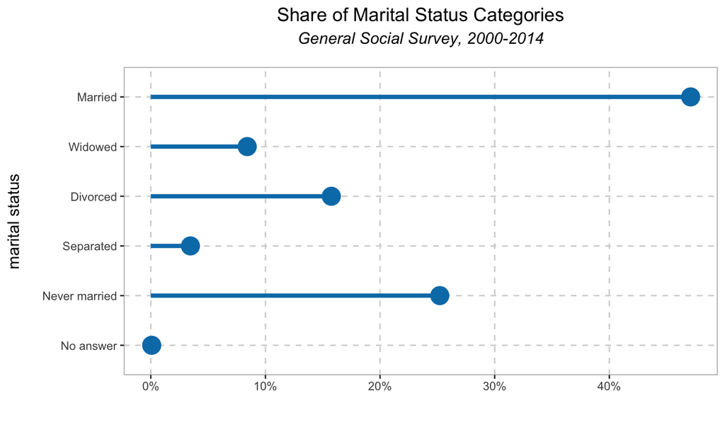

R displays factor information in charts (and tables) based on the variable’s defined levels.

While the chart was already quite informative, we may want to present the order of our variable in another manner.

## Reordering factors

## A. Reordering (manual)

We can reorder factor levels based on our desired arrangement.

One option is to **reorder factors manually** using the `fct_relevel()` function.

The following arguments need to be specified:  
1. the factor of interest (as a vector)  
2. the desired factor order

Recall, the levels of the `marital` variable:

```
## [1] "No answer"     "Never married" "Separated"     "Divorced"
## [5] "Widowed"       "Married"
```

## A. Reordering (manual)

If we want the category `Married` to be the first level, we can do so by specifying it as the second argument:

`fct_relevel(data$marital, "Married")`

```
## [1] "Married"       "No answer"     "Never married" "Separated"
## [5] "Divorced"      "Widowed"
```

We can also use the argument `after` to specify a position. This places `Widowed` after the 2nd level or in the 3rd place:

`fct_relevel(data$marital, "Widowed", after = 2)`

```
## [1] "Married"       "No answer"     "Widowed"       "Never married"
## [5] "Separated"     "Divorced"
```

This places `No answer` in the last place:

`fct_relevel(data$marital, "No answer", after = Inf)`

```
## [1] "Married"       "Widowed"       "Never married" "Separated"
## [5] "Divorced"      "No answer"
```

## A. Reordering (manual)

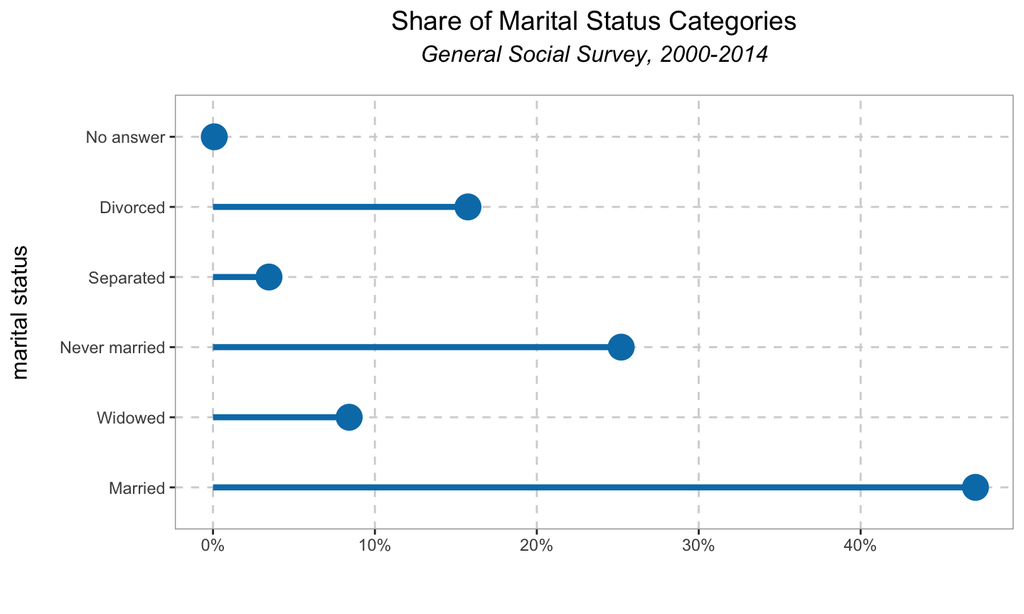

## B. Reordering (variable-based)

We can also reorder a factor **based on another variable.**

Suppose we want to plot marital status against another variable, `tvhours`, to determine the average number of hours spent watching TV by each group.

## B. Reordering (variable-based)

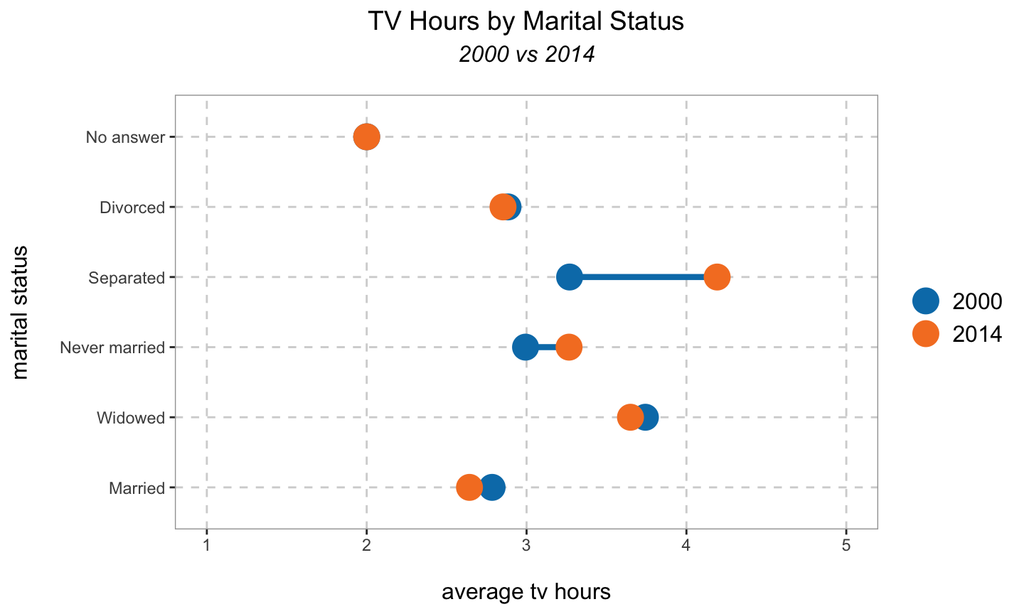

## B. Reordering (variable-based)

We can make the chart more readable by reporting the `marital` variable in order of average `tvhours`.

For variable-based reordering, we use the function `fct_reorder()`.

The following arguments need to be specified:  
1. the factor of interest (as a vector)  
2. the variable to base the order on

`levels(data$marital)`

```
## [1] "Married"       "Widowed"       "Never married" "Separated"
## [5] "Divorced"      "No answer"
```

`fct_reorder(data$marital, data$tvhours)`

```
## [1] "No answer"     "Married"       "Divorced"      "Never married"
## [5] "Widowed"       "Separated"
```

## B. Reordering (variable-based)

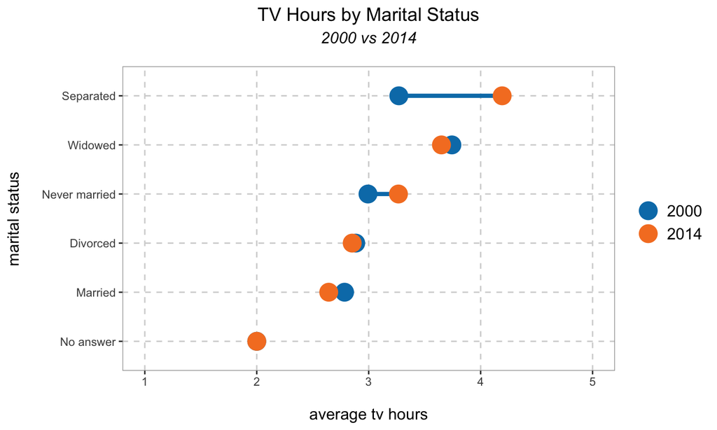

## C. Reordering (frequency-based)

We can also reorder factors **based on frequency**.

Suppose we want have a look at number of times each marital category appears in the sample.

| Marital Status | 2000 | 2014 |
| --- | --- | --- |
| Married | 1278 | 1158 |
| Widowed | 273 | 209 |
| Never married | 712 | 675 |
| Separated | 112 | 81 |
| Divorced | 441 | 411 |
| No answer | 1 | 4 |

## C. Reordering (frequency-based)

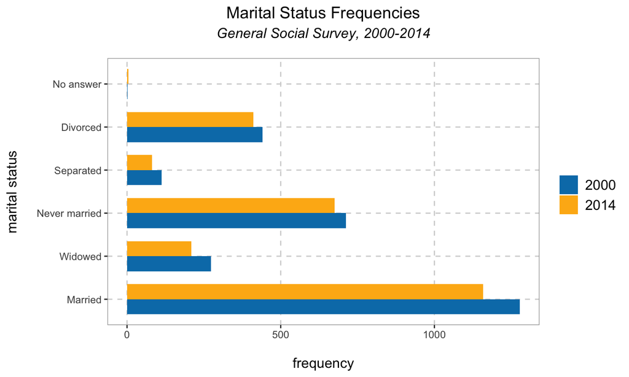

## C. Reordering (frequency-based)

We can easily reorder levels based on how frequent a value appears in the data using the function `fct_infreq()`.

`levels(data$marital)`

```
## [1] "Married"       "Widowed"       "Never married" "Separated"
## [5] "Divorced"      "No answer"
```

`fct_infreq(data$marital)`

```
## [1] "Married"       "Never married" "Divorced"      "Widowed"
## [5] "Separated"     "No answer"
```

## C. Reordering (frequency-based)

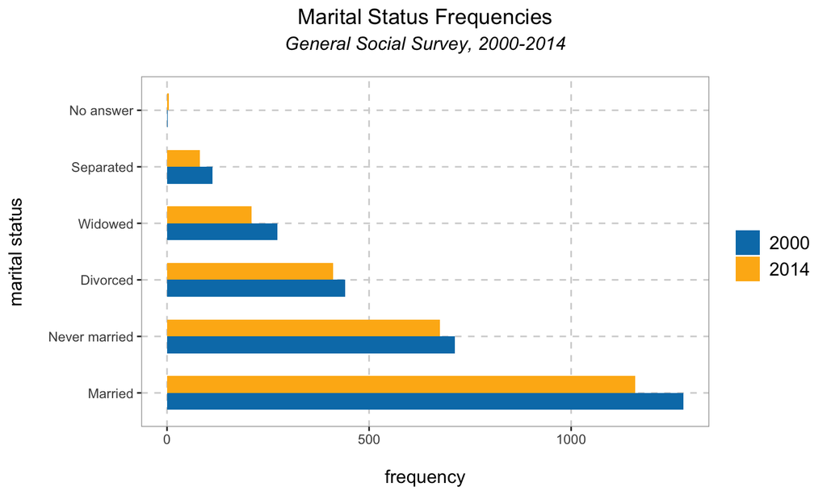

## D. Reordering (reverse)

Another useful function is **reversing the order** of levels using `fct_rev()`.

`levels(data$marital)`

```
## [1] "Married"       "Never married" "Divorced"      "Widowed"
## [5] "Separated"     "No answer"
```

`fct_rev(data$marital)`

```
## [1] "No answer"     "Separated"     "Widowed"       "Divorced"
## [5] "Never married" "Married"
```

## D. Reordering (reverse)

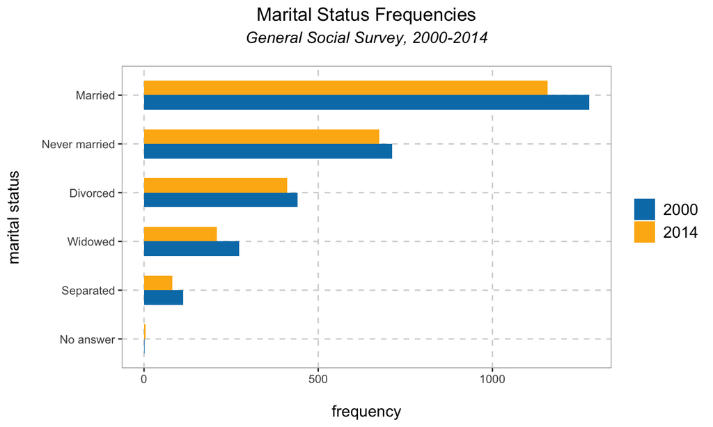

## Renaming factors

## Renaming factors

Another useful feature of `forcats` is changing level **values**. Doing so makes labels clearer for data visualization and also allows us to collapse and combine levels.

Take for example the `partyid` variable which shows the respondent’s party affiliation.

| Party | % Share |
| --- | --- |
| No answer | 0.72 |
| Don’t know | 0.00 |
| Other party | 1.83 |
| Strong republican | 10.77 |
| Not str republican | 14.11 |
| Ind,near rep | 8.34 |
| Independent | 19.17 |
| Ind,near dem | 11.63 |
| Not str democrat | 17.18 |
| Strong democrat | 16.25 |

## Renaming factors

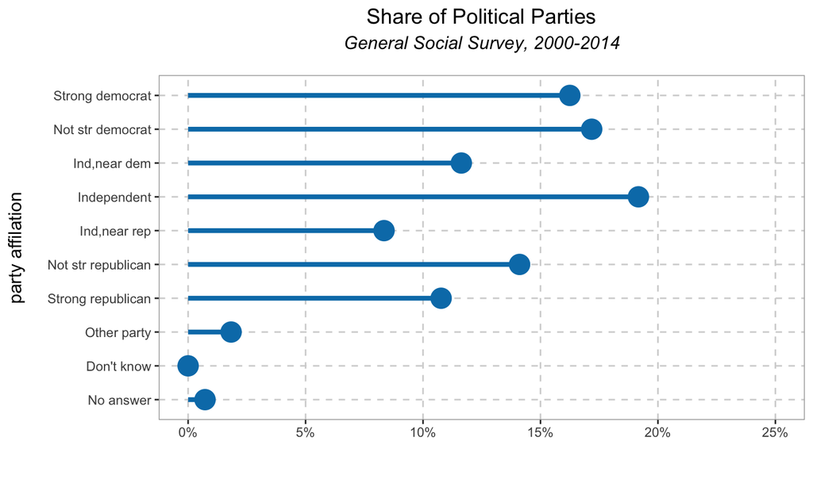

## A. Renaming (recoding)

We can use the `fct_recode()` function to clean up and standardize the values or labels of the factors.

The following arguments need to be specified:  
1. the factor of interest (as a vector)  
2. mapping of new and old factor values

`data %>%` `mutate(partyid = fct_recode(partyid,`  
`"Republican, strong" = "Strong republican",`  
`"Republican, weak" = "Not str republican",`  
`"Independent, near rep" = "Ind,near rep",`  
`"Independent, near dem" = "Ind,near dem",`  
`"Democrat, weak" = "Not str democrat",`  
`"Democrat, strong" = "Strong democrat"))`

## A. Renaming (recoding)

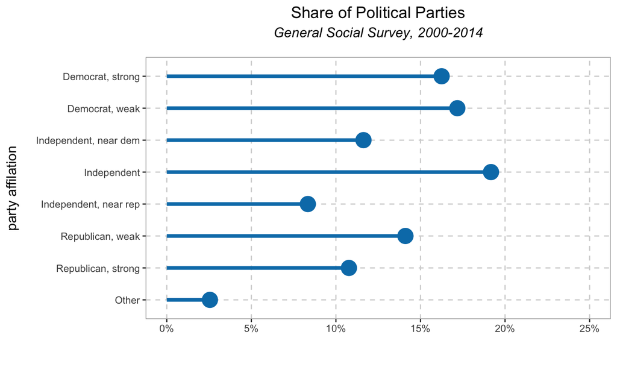

## B. Renaming (collapsing)

For combining multiple levels together, we can use the function is `fct_collapse()`.

The following arguments need to be specified:  
1. the factor of interest (as a vector)  
2. mapping of new values to a vector of old factor values

So if we want to combine all Republicans, Democrats and Independents:

`data %>%`  
`mutate(partyid = fct_collapse(partyid,`  
`Republican = str_subset(partyid, "Republican"),`  
`Independent = str_subset(partyid, "Independent"),`  
`Democrat = str_subset(partyid, "Democrat")))`

## B. Renaming (collapsing)

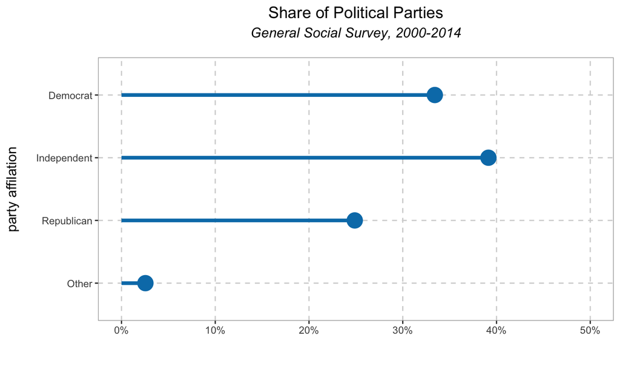

## C. Renaming (lumping)

If there are no specific values that we want to collapse together, we may also want to just lump the smallest values into a single category.

To do this we use the `fct_lump()` function.

The following arguments need to be specified:  
1. the factor of interest (as a vector)  
2. the number of categories that we want to retain

## C. Renaming (lumping)

We have the original table:

| Party | % Share |
| --- | --- |
| No answer | 0.72 |
| Don’t know | 0.00 |
| Other party | 1.83 |
| Strong republican | 10.77 |
| Not str republican | 14.11 |
| Ind,near rep | 8.34 |
| Independent | 19.17 |
| Ind,near dem | 11.63 |
| Not str democrat | 17.18 |
| Strong democrat | 16.25 |

## C. Renaming (lumping)

And we want to retain only the top 4 categories and move the rest to the *“Other”* category.

`data %>%` `mutate(partyid = fct_lump(partyid, n = 4))`

| Party | % Share |
| --- | --- |
| Not str republican | 14.11 |
| Independent | 19.17 |
| Not str democrat | 17.18 |
| Strong democrat | 16.25 |
| Other | 33.29 |

## C. Renaming (lumping)

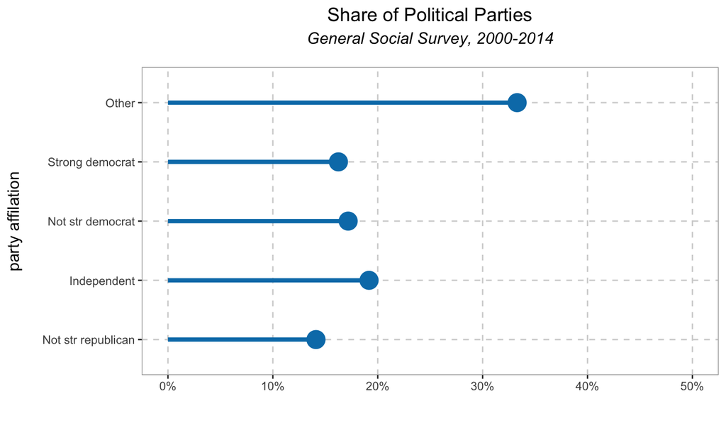

## C. Renaming (lumping)

As a review, we reorder the factor based on the share:

`data %>%` `mutate(partyid = fct_reorder(partyid, share))`

## C. Renaming (lumping)

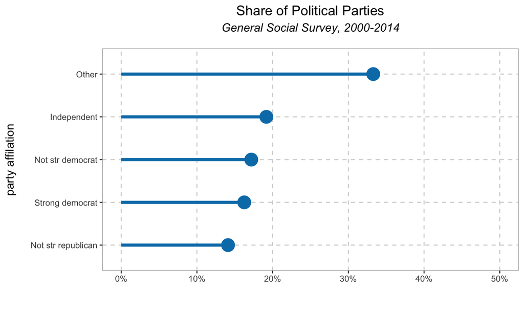

## Summary

## forcats functions

For **reordering factors**:

1. `fct_relevel()` - for reordering factors manually or by hand
2. `fct_reorder()` - for reordering factors based on another variable
3. `fct_infreq()` - for reordering factors based on frequency
4. `fct_rev()` - for reversing the order of factors

For **renaming factors**:

1. `fct_recode()` - for renaming factor levels manually or by hand
2. `fct_collapse()` - for combining multiple factor levels
3. `fct_lump()` - for combining most infrequent factor levels

## References

## References

1. Tidyverse forcats tutorial: https://forcats.tidyverse.org
2. R for Data Science, Chapter 15 Factors: https://r4ds.had.co.nz/factors.html
3. Wrangling Categorical Data in R (McNamara and Horton, 2017)